# Intro to dplyr and ggplot2

*Note: this tutorial originally comes from the wonderful people at [`software carpentry`](https://software-carpentry.org/lessons/).*

First, we need to make sure that we have the necessary packages installed.

```r
install.packages('tidyr')       # Includes a lot of pacakges, including dplyr and ggplot2
install.packages('gapminder')   # Has some fun data to play with.
```

Once they are, load the packages.

```r
library(gapminder)
library(tidyr)
library(dplyr)
```

```r
library(ggplot2)
```

I always like to use the `str` (which stands for structure) command to look what’s in a data frame:

```r
str(gapminder)
```

```
## Classes 'tbl_df', 'tbl' and 'data.frame':    1704 obs. of  6 variables:
##  $ country  : Factor w/ 142 levels "Afghanistan",..: 1 1 1 1 1 1 1 1 1 1 ...
##  $ continent: Factor w/ 5 levels "Africa","Americas",..: 3 3 3 3 3 3 3 3 3 3 ...
##  $ year     : int  1952 1957 1962 1967 1972 1977 1982 1987 1992 1997 ...
##  $ lifeExp  : num  28.8 30.3 32 34 36.1 ...
##  $ pop      : int  8425333 9240934 10267083 11537966 13079460 14880372 12881816 13867957 16317921 22227415 ...
##  $ gdpPercap: num  779 821 853 836 740 ...
```

And some summary stats:

```r
summary(gapminder)
```

```
##         country        continent        year         lifeExp
##  Afghanistan:  12   Africa  :624   Min.   :1952   Min.   :23.60
##  Albania    :  12   Americas:300   1st Qu.:1966   1st Qu.:48.20
##  Algeria    :  12   Asia    :396   Median :1980   Median :60.71
##  Angola     :  12   Europe  :360   Mean   :1980   Mean   :59.47
##  Argentina  :  12   Oceania : 24   3rd Qu.:1993   3rd Qu.:70.85
##  Australia  :  12                  Max.   :2007   Max.   :82.60
##  (Other)    :1632
##       pop              gdpPercap
##  Min.   :6.001e+04   Min.   :   241.2
##  1st Qu.:2.794e+06   1st Qu.:  1202.1
##  Median :7.024e+06   Median :  3531.8
##  Mean   :2.960e+07   Mean   :  7215.3
##  3rd Qu.:1.959e+07   3rd Qu.:  9325.5
##  Max.   :1.319e+09   Max.   :113523.1
##
```

Manipulation of dataframes means many things to many researchers, we often select certain observations (rows) or variables (columns), we often group the data by a certain variable(s), or we even calculate summary statistics. We can do these operations using the normal base R operations:

```r
mean(gapminder[gapminder$continent == "Africa", ]$gdpPercap)
```

```
## [1] 2193.755
```

```r
mean(gapminder[gapminder$continent == "Americas", ]$gdpPercap)
```

```
## [1] 7136.11
```

```r
mean(gapminder[gapminder$continent == "Asia", ]$gdpPercap)
```

```
## [1] 7902.15
```

But this isn’t very *nice* because there is a fair bit of repetition. Repeating yourself will cost you time, both now and later, and potentially introduce some nasty bugs.

## The `dplyr` package

Luckily, the [`dplyr`](https://cran.r-project.org/web/packages/dplyr/dplyr.pdf) package provides a number of very useful functions for manipulating dataframes in a way that will reduce the above repetition, reduce the probability of making errors, and probably even save you some typing. As an added bonus, you might even find the `dplyr` grammar easier to read.

1. `select()`
2. `filter()`
3. `group_by()`
4. `summarize()`
5. `mutate()`

# Using select()

If, for example, we wanted to move forward with only a few of the variables in our dataframe we could use the `select()` function. This will keep only the variables you select.

```r
select(gapminder,year,country,gdpPercap)
```

```
## # A tibble: 1,704 × 3
##     year     country gdpPercap
##    <int>      <fctr>     <dbl>
## 1   1952 Afghanistan  779.4453
## 2   1957 Afghanistan  820.8530
## 3   1962 Afghanistan  853.1007
## 4   1967 Afghanistan  836.1971
## 5   1972 Afghanistan  739.9811
## 6   1977 Afghanistan  786.1134
## 7   1982 Afghanistan  978.0114
## 8   1987 Afghanistan  852.3959
## 9   1992 Afghanistan  649.3414
## 10  1997 Afghanistan  635.3414
## # ... with 1,694 more rows
```

```r
gapminder %>% select(year,country,gdpPercap)
```

```
## # A tibble: 1,704 × 3
##     year     country gdpPercap
##    <int>      <fctr>     <dbl>
## 1   1952 Afghanistan  779.4453
## 2   1957 Afghanistan  820.8530
## 3   1962 Afghanistan  853.1007
## 4   1967 Afghanistan  836.1971
## 5   1972 Afghanistan  739.9811
## 6   1977 Afghanistan  786.1134
## 7   1982 Afghanistan  978.0114
## 8   1987 Afghanistan  852.3959
## 9   1992 Afghanistan  649.3414
## 10  1997 Afghanistan  635.3414
## # ... with 1,694 more rows
```

To help you understand why we wrote that in that way, let’s walk through it step by step. First we summon the gapminder dataframe and pass it on, using the pipe symbol `%>%`, to the next step, which is the `select()` function. In this case we don’t specify which data object we use in the `select()` function since in gets that from the previous pipe. **Fun Fact**: There is a good chance you have encountered pipes before in the shell. In R, a pipe symbol is `%>%` while in the shell it is `|` but the concept is the same!

## Using filter()

If we now wanted to move forward with the above, but only with European countries, we can combine `select` and `filter`

```r
gapminder %>%
    filter(continent=="Europe") %>%
    select(year,country,gdpPercap)
```

```
## # A tibble: 360 × 3
##     year country gdpPercap
##    <int>  <fctr>     <dbl>
## 1   1952 Albania  1601.056
## 2   1957 Albania  1942.284
## 3   1962 Albania  2312.889
## 4   1967 Albania  2760.197
## 5   1972 Albania  3313.422
## 6   1977 Albania  3533.004
## 7   1982 Albania  3630.881
## 8   1987 Albania  3738.933
## 9   1992 Albania  2497.438
## 10  1997 Albania  3193.055
## # ... with 350 more rows
```

## Challenge 1

Write a command that will produce a dataframe that has the African values for `lifeExp`, `country` and `year`, but not for other Continents. How many rows does your dataframe have?

## Solution to Challenge 1

```r
#TODO: Your code here
```

## Using group_by() and summarize()

Now, we were supposed to be reducing the error prone repetitiveness of what can be done with base R, but up to now we haven’t done that since we would have to repeat the above for each continent. Instead of `filter()`, which will only pass observations that meet your criteria (in the above: `continent=="Europe"`), we can use `group_by()`, which will essentially use every unique criteria that you could have used in filter.

```r
str(gapminder)
```

```
## Classes 'tbl_df', 'tbl' and 'data.frame':    1704 obs. of  6 variables:
##  $ country  : Factor w/ 142 levels "Afghanistan",..: 1 1 1 1 1 1 1 1 1 1 ...
##  $ continent: Factor w/ 5 levels "Africa","Americas",..: 3 3 3 3 3 3 3 3 3 3 ...
##  $ year     : int  1952 1957 1962 1967 1972 1977 1982 1987 1992 1997 ...
##  $ lifeExp  : num  28.8 30.3 32 34 36.1 ...
##  $ pop      : int  8425333 9240934 10267083 11537966 13079460 14880372 12881816 13867957 16317921 22227415 ...
##  $ gdpPercap: num  779 821 853 836 740 ...
```

```r
str(gapminder %>% group_by(continent))
```

```
## Classes 'grouped_df', 'tbl_df', 'tbl' and 'data.frame':  1704 obs. of  6 variables:
##  $ country  : Factor w/ 142 levels "Afghanistan",..: 1 1 1 1 1 1 1 1 1 1 ...
##  $ continent: Factor w/ 5 levels "Africa","Americas",..: 3 3 3 3 3 3 3 3 3 3 ...
##  $ year     : int  1952 1957 1962 1967 1972 1977 1982 1987 1992 1997 ...
##  $ lifeExp  : num  28.8 30.3 32 34 36.1 ...
##  $ pop      : int  8425333 9240934 10267083 11537966 13079460 14880372 12881816 13867957 16317921 22227415 ...
##  $ gdpPercap: num  779 821 853 836 740 ...
##  - attr(*, "vars")=List of 1
##   ..$ : symbol continent
##  - attr(*, "drop")= logi TRUE
##  - attr(*, "indices")=List of 5
##   ..$ : int  24 25 26 27 28 29 30 31 32 33 ...
##   ..$ : int  48 49 50 51 52 53 54 55 56 57 ...
##   ..$ : int  0 1 2 3 4 5 6 7 8 9 ...
##   ..$ : int  12 13 14 15 16 17 18 19 20 21 ...
##   ..$ : int  60 61 62 63 64 65 66 67 68 69 ...
##  - attr(*, "group_sizes")= int  624 300 396 360 24
##  - attr(*, "biggest_group_size")= int 624
##  - attr(*, "labels")='data.frame':   5 obs. of  1 variable:
##   ..$ continent: Factor w/ 5 levels "Africa","Americas",..: 1 2 3 4 5
##   ..- attr(*, "vars")=List of 1
##   .. ..$ : symbol continent
##   ..- attr(*, "drop")= logi TRUE
```

You will notice that the structure of the dataframe where we used `group_by()` (`grouped_df`) is not the same as the original `gapminder` (`data.frame`). A `grouped_df` can be thought of as a `list` where each item in the `list` is a `data.frame` which contains only the rows that correspond to the a particular value `continent` (at least in the example above).

## Using summarize()

The above was a bit on the uneventful side because `group_by()` much more exciting in conjunction with `summarize()`. This will allow use to create new variable(s) by using functions that repeat for each of the continent-specific data frames. That is to say, using the `group_by()` function, we split our original dataframe into multiple pieces, then we can run functions (e.g. `mean()` or `sd()`) within `summarize()`.

```r
gdp_bycontinents <- gapminder %>%
    group_by(continent) %>%
    summarize(mean_gdpPercap=mean(gdpPercap))
```

That allowed us to calculate the mean gdpPercap for each continent, but it gets even better.

## Challenge 2

Calculate the average life expectancy per country. Which has the longest average life expectancy and which has the shortest average life expectancy?

## Solution to Challenge 2

```r
#TODO: Your code here
```

The function `group_by()` allows us to group by multiple variables. Let’s group by `year` and `continent`.

```r
gapminder %>%
    group_by(continent,year) %>%
    summarize(mean_gdpPercap=mean(gdpPercap))
```

```
## Source: local data frame [60 x 3]
## Groups: continent [?]
##
##    continent  year mean_gdpPercap
##       <fctr> <int>          <dbl>
## 1     Africa  1952       1252.572
## 2     Africa  1957       1385.236
## 3     Africa  1962       1598.079
## 4     Africa  1967       2050.364
## 5     Africa  1972       2339.616
## 6     Africa  1977       2585.939
## 7     Africa  1982       2481.593
## 8     Africa  1987       2282.669
## 9     Africa  1992       2281.810
## 10    Africa  1997       2378.760
## # ... with 50 more rows
```

That is already quite powerful, but it gets even better! You’re not limited to defining 1 new variable in `summarize()`.

```r
gapminder %>%
    group_by(continent,year) %>%
    summarize(mean_gdpPercap=mean(gdpPercap),
              sd_gdpPercap=sd(gdpPercap),
              mean_pop=mean(pop),
              sd_pop=sd(pop))
```

```
## Source: local data frame [60 x 6]
## Groups: continent [?]
##
##    continent  year mean_gdpPercap sd_gdpPercap mean_pop   sd_pop
##       <fctr> <int>          <dbl>        <dbl>    <dbl>    <dbl>
## 1     Africa  1952       1252.572     982.9521  4570010  6317450
## 2     Africa  1957       1385.236    1134.5089  5093033  7076042
## 3     Africa  1962       1598.079    1461.8392  5702247  7957545
## 4     Africa  1967       2050.364    2847.7176  6447875  8985505
## 5     Africa  1972       2339.616    3286.8539  7305376 10130833
## 6     Africa  1977       2585.939    4142.3987  8328097 11585184
## 7     Africa  1982       2481.593    3242.6328  9602857 13456243
## 8     Africa  1987       2282.669    2566.5319 11054502 15277484
## 9     Africa  1992       2281.810    2644.0756 12674645 17562719
## 10    Africa  1997       2378.760    2820.7281 14304480 19873013
## # ... with 50 more rows
```

## count() and n()

A very common operation is to count the number of observations for each group. The `dplyr` package comes with two related functions that help with this.

For instance, if we wanted to check the number of countries included in the dataset for the year 2002, we can use the `count()` function. It takes the name of one or more columns that contain the groups we are interested in, and we can optionally sort the results in descending order by adding `sort=TRUE`:

```r
gapminder %>%
    filter(year == 2002) %>%
    count(continent, sort = TRUE)
```

```
## # A tibble: 5 × 2
##   continent     n
##      <fctr> <int>
## 1    Africa    52
## 2      Asia    33
## 3    Europe    30
## 4  Americas    25
## 5   Oceania     2
```

If we need to use the number of observations in calculations, the `n()` function is useful. For instance, if we wanted to get the standard error of the life expectency per continent:

```r
gapminder %>%
    group_by(continent) %>%
    summarize(se_pop = sd(lifeExp)/sqrt(n()))
```

```
## # A tibble: 5 × 2
##   continent    se_pop
##      <fctr>     <dbl>
## 1    Africa 0.3663016
## 2  Americas 0.5395389
## 3      Asia 0.5962151
## 4    Europe 0.2863536
## 5   Oceania 0.7747759
```

## Using mutate()

We can also create new variables prior to (or even after) summarizing information using `mutate()`.

```r
gapminder %>%
    mutate(gdp_billion=gdpPercap*pop/10^9) %>%
    group_by(continent,year) %>%
    summarize(mean_gdpPercap=mean(gdpPercap),
              sd_gdpPercap=sd(gdpPercap),
              mean_pop=mean(pop),
              sd_pop=sd(pop),
              mean_gdp_billion=mean(gdp_billion),
              sd_gdp_billion=sd(gdp_billion))
```

```
## Source: local data frame [60 x 8]
## Groups: continent [?]
##
##    continent  year mean_gdpPercap sd_gdpPercap mean_pop   sd_pop
##       <fctr> <int>          <dbl>        <dbl>    <dbl>    <dbl>
## 1     Africa  1952       1252.572     982.9521  4570010  6317450
## 2     Africa  1957       1385.236    1134.5089  5093033  7076042
## 3     Africa  1962       1598.079    1461.8392  5702247  7957545
## 4     Africa  1967       2050.364    2847.7176  6447875  8985505
## 5     Africa  1972       2339.616    3286.8539  7305376 10130833
## 6     Africa  1977       2585.939    4142.3987  8328097 11585184
## 7     Africa  1982       2481.593    3242.6328  9602857 13456243
## 8     Africa  1987       2282.669    2566.5319 11054502 15277484
## 9     Africa  1992       2281.810    2644.0756 12674645 17562719
## 10    Africa  1997       2378.760    2820.7281 14304480 19873013
## # ... with 50 more rows, and 2 more variables: mean_gdp_billion <dbl>,
## #   sd_gdp_billion <dbl>
```

## Connect mutate with logical filtering: ifelse

When creating new variables, we can hook this with a logical condition. A simple combination of `mutate()` and `ifelse()` facilitates filtering right where it is needed: in the moment of creating something new. This easy-to-read statement is a fast and powerful way of discarding certain data (even though the overall dimension of the data frame will not change) or for updating values depending on this given condition.

```r
## keeping all data but "filtering" after a certain condition
# calculate GDP only for people with a life expectation above 25
gapminder %>%
    mutate(gdp_billion = ifelse(lifeExp > 25, gdpPercap * pop / 10^9, NA)) %>%
    group_by(continent, year) %>%
    summarize(mean_gdpPercap = mean(gdpPercap),
              sd_gdpPercap = sd(gdpPercap),
              mean_pop = mean(pop),
              sd_pop = sd(pop),
              mean_gdp_billion = mean(gdp_billion),
              sd_gdp_billion = sd(gdp_billion))
```

```
## Source: local data frame [60 x 8]
## Groups: continent [?]
##
##    continent  year mean_gdpPercap sd_gdpPercap mean_pop   sd_pop
##       <fctr> <int>          <dbl>        <dbl>    <dbl>    <dbl>
## 1     Africa  1952       1252.572     982.9521  4570010  6317450
## 2     Africa  1957       1385.236    1134.5089  5093033  7076042
## 3     Africa  1962       1598.079    1461.8392  5702247  7957545
## 4     Africa  1967       2050.364    2847.7176  6447875  8985505
## 5     Africa  1972       2339.616    3286.8539  7305376 10130833
## 6     Africa  1977       2585.939    4142.3987  8328097 11585184
## 7     Africa  1982       2481.593    3242.6328  9602857 13456243
## 8     Africa  1987       2282.669    2566.5319 11054502 15277484
## 9     Africa  1992       2281.810    2644.0756 12674645 17562719
## 10    Africa  1997       2378.760    2820.7281 14304480 19873013
## # ... with 50 more rows, and 2 more variables: mean_gdp_billion <dbl>,
## #   sd_gdp_billion <dbl>
```

```r
## updating only if certain condition is fullfilled
# for life expectations above 40 years, the gpd to be expected in the future is scaled
gapminder %>%
    mutate(gdp_futureExpectation = ifelse(lifeExp > 40, gdpPercap * 1.5, gdpPercap)) %>%
    group_by(continent, year) %>%
    summarize(mean_gdpPercap = mean(gdpPercap),
              mean_gdpPercap_expected = mean(gdp_futureExpectation))
```

```
## Source: local data frame [60 x 4]
## Groups: continent [?]
##
##    continent  year mean_gdpPercap mean_gdpPercap_expected
##       <fctr> <int>          <dbl>                   <dbl>
## 1     Africa  1952       1252.572                1577.785
## 2     Africa  1957       1385.236                1802.729
## 3     Africa  1962       1598.079                2226.807
## 4     Africa  1967       2050.364                2953.474
## 5     Africa  1972       2339.616                3415.900
## 6     Africa  1977       2585.939                3829.661
## 7     Africa  1982       2481.593                3673.735
## 8     Africa  1987       2282.669                3400.636
## 9     Africa  1992       2281.810                3396.439
## 10    Africa  1997       2378.760                3556.941
## # ... with 50 more rows
```

## Combining `dplyr` and `ggplot2`

`ggplot2` is a powerful graphics package for producing beautiful, comprehensive, plots and graphs. Once you understand how it works, it’s actually very simple to use.

Let’s use `filter` to just give us one country’s data, and then pass that along to `ggplot2` to make a line plot.

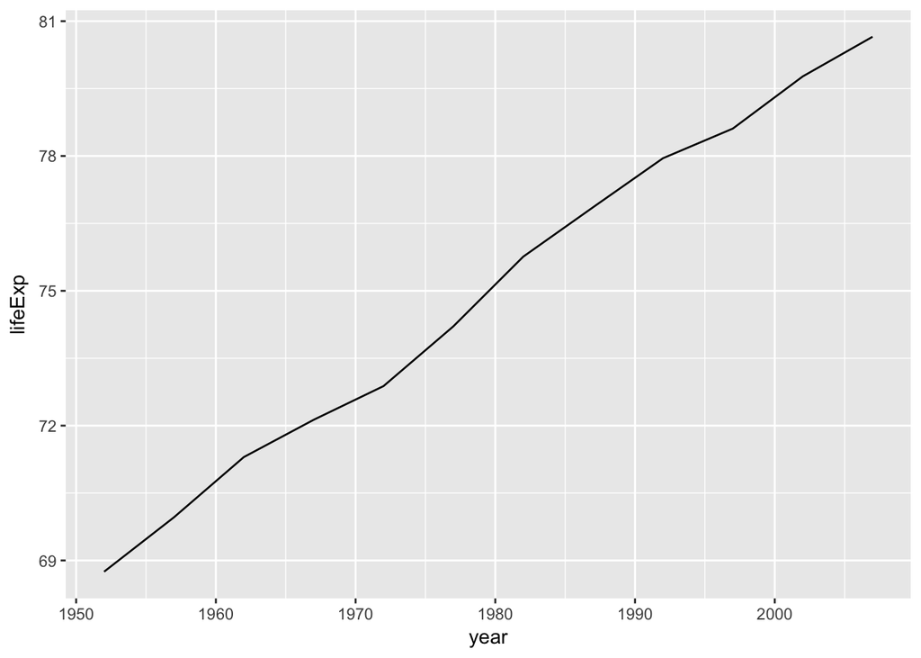

```r
gapminder %>%
  filter(country == "Canada") %>%
  ggplot(aes(x = year, y = lifeExp)) +
  geom_line()
```

We can even plot more than one country.

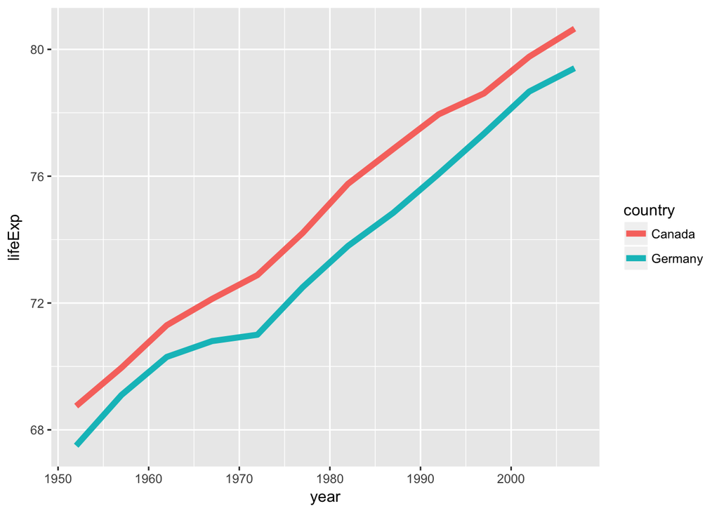

```r
gapminder %>%
  filter(country %in% c("Canada", "Germany")) %>%
  ggplot(aes(x = year, y = lifeExp, color=country)) +
  geom_line(size=2)
```

We can plot them separately, in what `ggplot2` calls “facets.”

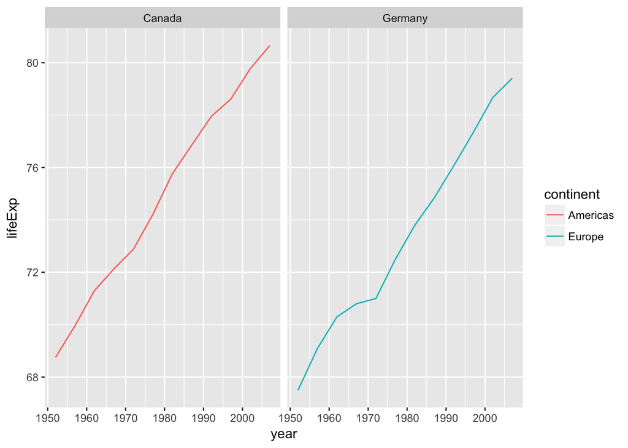

```r
gapminder %>%
  filter(country %in% c("Canada", "Germany")) %>%
  ggplot(aes(x = year, y = lifeExp, color=continent)) +
  geom_line() + facet_wrap ( ~ country)
```

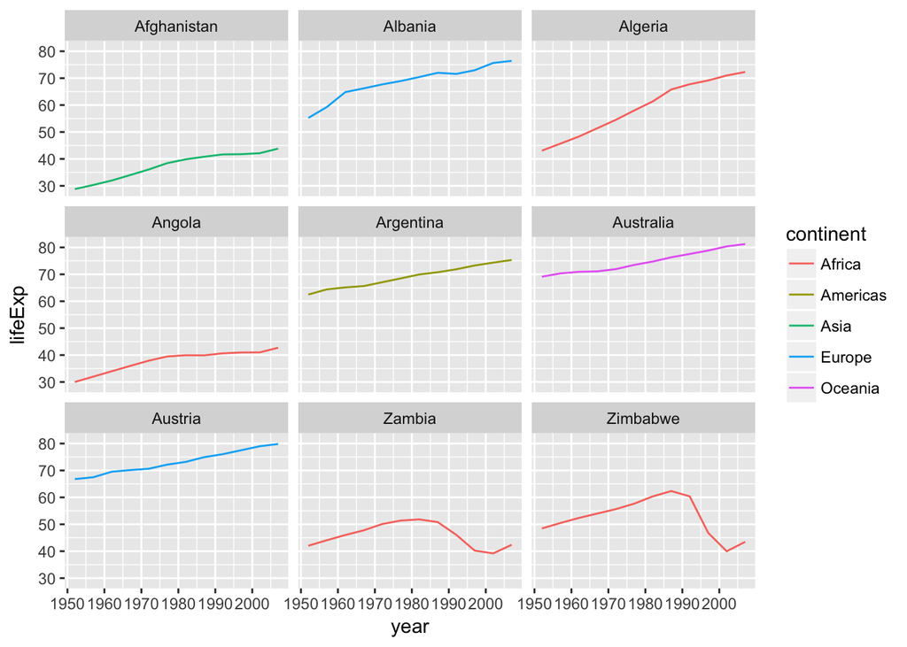

```r
gapminder %>%
   # Get the start letter of each country
   mutate(startsWith = substr(country, start = 1, stop = 1)) %>%
   # Filter countries that start with "A" or "Z"
   filter(startsWith %in% c("A", "Z")) %>%
   # Make the plot
   ggplot(aes(x = year, y = lifeExp, color = continent)) +
   geom_line() +
   facet_wrap( ~ country)
```

Using `dplyr` functions also helps us simplify things, for example we could combine the first two steps:

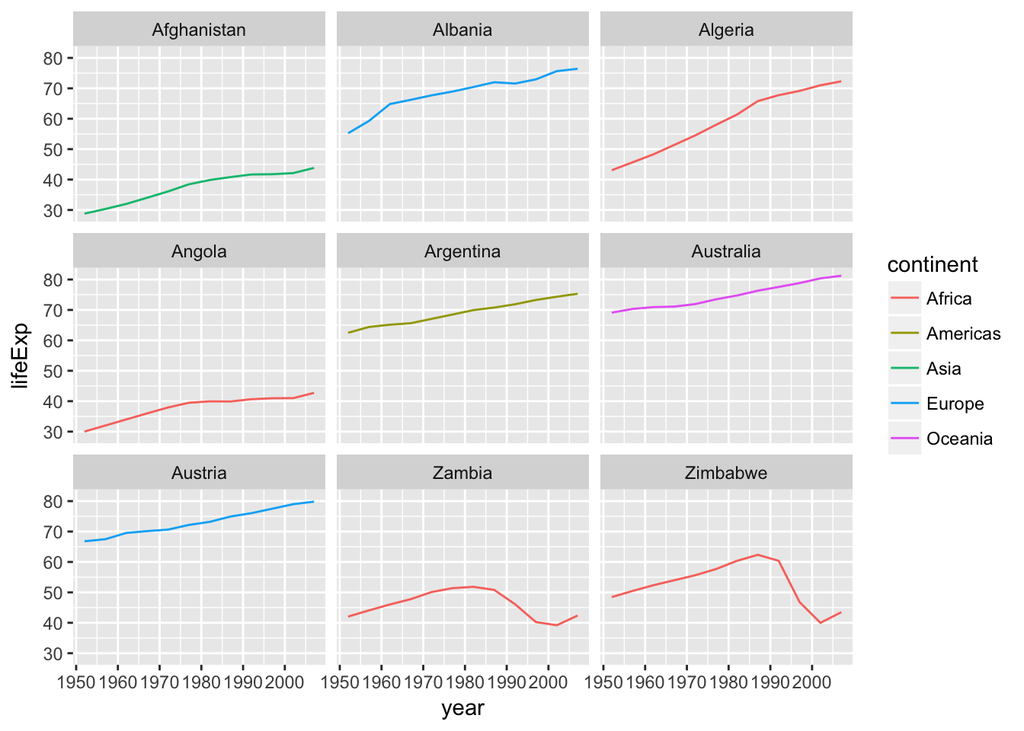

```r
gapminder %>%
    # Filter countries that start with "A" or "Z"
    filter(substr(country, start = 1, stop = 1) %in% c("A", "Z")) %>%
    # Make the plot
    ggplot(aes(x = year, y = lifeExp, color = continent)) +
    geom_line() +
    facet_wrap( ~ country)
```

## Solutions to challenges

#### Challenge 1

```
## # A tibble: 624 × 3
##     year country lifeExp
##    <int>  <fctr>   <dbl>
## 1   1952 Algeria  43.077
## 2   1957 Algeria  45.685
## 3   1962 Algeria  48.303
## 4   1967 Algeria  51.407
## 5   1972 Algeria  54.518
## 6   1977 Algeria  58.014
## 7   1982 Algeria  61.368
## 8   1987 Algeria  65.799
## 9   1992 Algeria  67.744
## 10  1997 Algeria  69.152
## # ... with 614 more rows
```

#### Challenge 2

```
## # A tibble: 2 × 2
##        country mean_lifeExp
##         <fctr>        <dbl>
## 1      Iceland     76.51142
## 2 Sierra Leone     36.76917
```

```r
# Another way to do this is to use the `dplyr` function `arrange()`, which
# arranges the rows in a data frame according to the order of one or more
# variables from the data frame.  It has similar syntax to other functions from
# the `dplyr` package. You can use `desc()` inside `arrange()` to sort in
# descending order.

lifeExp_bycountry %>%
    arrange(mean_lifeExp) %>%
    head(1)
```

```
## # A tibble: 1 × 2
##        country mean_lifeExp
##         <fctr>        <dbl>
## 1 Sierra Leone     36.76917
```

```r
lifeExp_bycountry %>%
    arrange(desc(mean_lifeExp)) %>%
    head(1)
```

```
## # A tibble: 1 × 2
##   country mean_lifeExp
##    <fctr>        <dbl>
## 1 Iceland     76.51142
```

```
## # A tibble: 5 × 2
##   continent mean_lifeExp
##      <fctr>        <dbl>
## 1   Oceania      79.7400
## 2    Europe      75.6900
## 3  Americas      66.2385
## 4      Asia      52.0710
## 5    Africa      46.2410
```